# Perth Airport Rainfall Analysis 🛫

# Rainfall analysis and prediction for Perth Airport

Having recently moved to Perth from Newcaslte I am intrigued by the different weather patterns here in Perth. The most striking feature is that rainfall in Perth is *seasonal* while in Newcastle it is mostly constant year round.

So I wanted to explore the nature of rainfall in Perth. Fortunately, it is easy to get data for any Australian weather site from the [Bureau of Meterology website](http://www.bom.gov.au/climate/data/?ref=ftr).

The data I am using in this notebook is the daily rainfall totals for Perth Airport weather station. It has been continuously monitoring rainfall since May 1944! This allows us to get a good grasp on the seasonal rainfall patterns in Perth and also what the year to year trend looks like.

## code setup

Libraries:

```r
suppressMessages(library(data.table))
suppressMessages(library(tidyverse))
suppressMessages(library(splines))
suppressMessages(library(ggdark))
suppressMessages(library(patchwork))
require(gridExtra)
```

## import and clean data

Import data and drop missing rainfall rows.

```r
rainRaw <- fread("airport_data/IDCJAC0009_009021_1800_Data.csv")
#remove nan rainfall rows, no rainfall is represented by 0,
# NaN is not observed/recorded in this dataset
rain <- rainRaw %>% drop_na("Rainfall amount (millimetres)")
rain %>% head(2)
```

| Product code | Bureau of Meteorology station number | Year | Month | Day | Rainfall amount (millimetres) | Period over which rainfall was measured (days) | Quality |
| --- | --- | --- | --- | --- | --- | --- | --- |
| IDCJAC0009 | 9021 | 1944 | 5 | 1 | 0 | NA | Y |
| IDCJAC0009 | 9021 | 1944 | 5 | 2 | 0 | NA | Y |

Add some useful columns to our rain dataframe:

```r
#boolean for whether it rained at all
rain <- rain %>%
    mutate(did_rain = `Rainfall amount (millimetres)` > 0)
```

## Should you plan to go outside? Percent chance of any rain for Perth Airport

Probably the most striking feature of rain in Perth is just how seasonal it is. Looking at our first graph below we can see any given day in January has less than 10% chance of any rain while a given day in July has over 50% chance of any rain! The month to month change is dramatic, with the change in rainfall chance shifting rapidly in autumn and spring.

While summers are incredibly hot, and the UV index is dangerous, summer is a great time to plan outdoor activities that would be otherwise ruined by rain. In contrast, expect the opposite in winter.

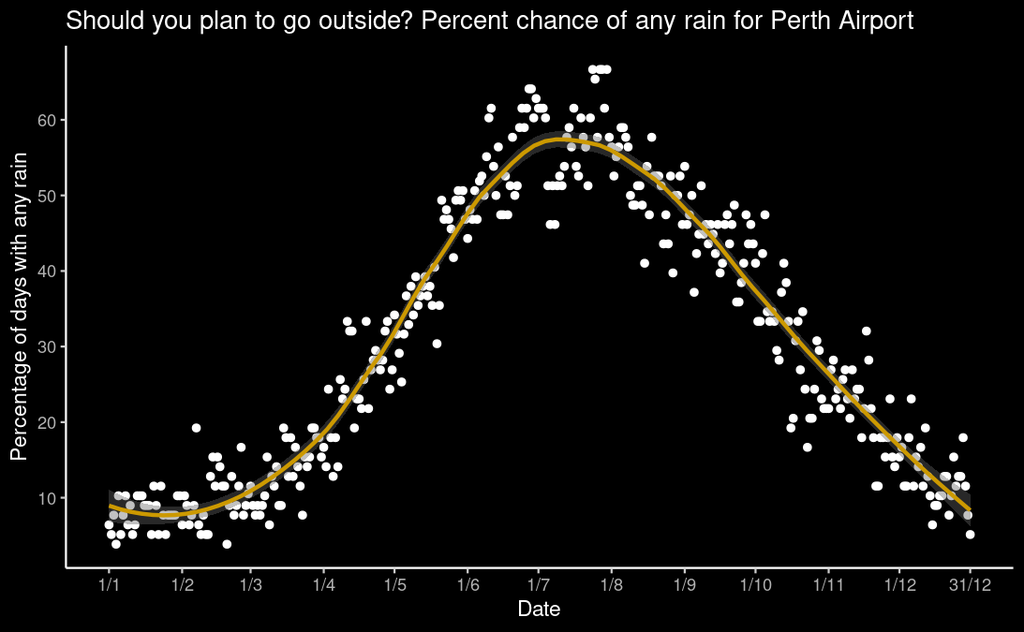

```r
rainy_days <- rain %>%
    group_by(Month, Day) %>%
    summarise(
      number_of_rainy_days = sum(did_rain), days_observed = n()
    ) %>%
    mutate(proportion_rained = number_of_rainy_days/days_observed)

rainy_days$index <- 1:length(rainy_days$Day)
rainy_days <- rainy_days %>%
  mutate(date_str = str_c(Day, Month, sep = "/"))
custom_breaks = c(
    1,32,32+29,32+29+31,92+30,153,153+30,214,245,275,306,336,366
)
rainy_days %>%
    ggplot(aes(index, proportion_rained*100)) +
    geom_point() +
    geom_smooth(span=0.5) +
    scale_y_continuous(breaks = seq(0,1,0.1)*100) +
    ylab("Percentage of days with any rain") +
    xlab("Date") +
    scale_x_continuous(
      breaks = custom_breaks, labels = rainy_days$date_str[custom_breaks]
    ) +
    ggtitle("Should you plan to go outside? Percent chance of any rain for Perth Airport") +
    dark_theme_classic()
```

## Changing rainfall with climate change

Perth is experiencing huge changes to it’s rainfall. We can illustrate this in our next plot that shows the total rainfall each year. As we can there is steady trend of decreasing rainfall year-on-year.

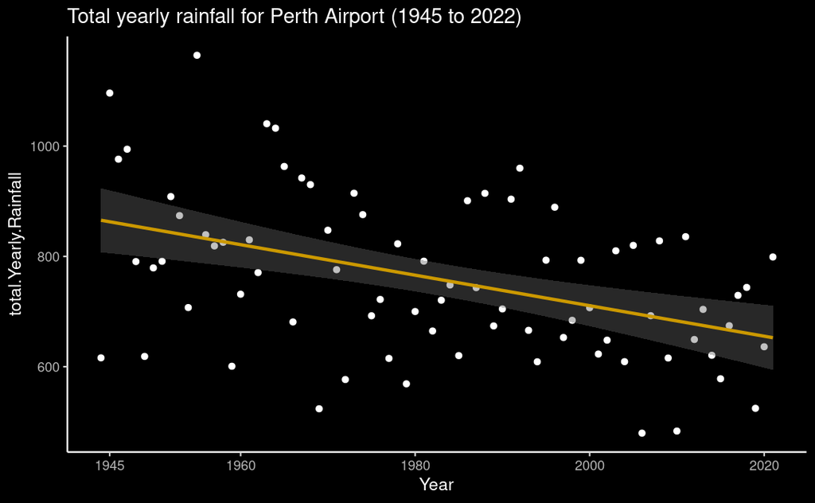

```r
rainfall_totals_yearly <- rain %>%
  filter(Year != 2022) %>%
  group_by(Year) %>% summarise(total.Yearly.Rainfall = sum(`Rainfall amount (millimetres)`))

rainfall_totals_yearly %>%
  ggplot(aes(Year, total.Yearly.Rainfall)) +
  geom_point() +
  geom_smooth(method="lm") +
  scale_x_continuous(breaks = c(1945,1960,1980,2000,2020)) +
  ggtitle("Total yearly rainfall for Perth Airport (1945 to 2022)") +
  dark_theme_classic()
```

To get some specific numbers on this, we can run a linear regression and consider the intercept and slope. This will produce the same result as the line through the graph above, as `ggplot::geom_smooth(method="lm")` is using the same function as below (`lm()`).

```r
#to use our intercept we set 1944 to be "year zero"
base_year = 1944
rainfall_totals_yearly <- rainfall_totals_yearly %>% mutate(Year_zeroed = Year-base_year)
rainfall_model_lm <- lm("total.Yearly.Rainfall ~ Year_zeroed" , data = rainfall_totals_yearly)
broom::tidy(summary(rainfall_model_lm))
```

| term | estimate | std.error | statistic | p.value |
| --- | --- | --- | --- | --- |
| (Intercept) | 865.566537 | 29.1842446 | 29.65869 | 1.575382e-43 |
| Year_zeroed | -2.766197 | 0.6543542 | -4.22737 | 6.515345e-05 |

```r
Years = c(1950, 1970, 2020, 2040, 2080, 2100, 2200)
df <- broom::tidy(predict(
  rainfall_model_lm, list(
    Year_zeroed=Years-base_year
  )
))
df$Year <- Years
df$Predicted_Rainfall <- df$x
df <- merge(df, rainfall_totals_yearly %>%
  filter(Year %in% Years) %>% select(Year, total.Yearly.Rainfall) %>%
    rename(Actual_rainfall = total.Yearly.Rainfall),
  all.x = TRUE)
df %>%
  select(Year, Predicted_Rainfall, Actual_rainfall) %>%
  mutate(Difference = Actual_rainfall - Predicted_Rainfall)
```

| Year | Predicted_Rainfall | Actual_rainfall | Difference |
| --- | --- | --- | --- |
| 1950 | 848.9694 | 779.2 | -69.76935 |
| 1970 | 793.6454 | 847.5 | 53.85459 |
| 2020 | 655.3356 | 636.2 | -19.13556 |
| 2040 | 600.0116 | NA | NA |
| 2080 | 489.3637 | NA | NA |
| 2100 | 434.0398 | NA | NA |
| 2200 | 157.4201 | NA | NA |

## Changing rainfall, a deeper dive

This dataset is large enough for us to consider a deeper dive into Perth’s changing rainfall. We can explore a few questions with graphs and statistical models: 1. in which months is rainfall increasing or decreasing? 2. is the time of peak rainfall each year changing or constant?

## in which months is rainfall increasing or decreasing?

It is interesting to consider whether rainfall patterns are changing in the same way for all months and times of year. We can use linear models to approach this in two different ways:

1. We can run linear models of `Year = total_rainfall` separately for each month
2. We can use a single linear model with month as an interaction term, i.e `Year = total_rainfall * month`

### linear models for each month

While the latter is more elegant, the former is easier to illustrate on a graph. We can see the results on the graph below (“Perth rainfall monthly totals”). Here, we can see that the relationship between Total Rainfall and Year differs across the year. We can also plot in on the winter and summer months to get a better feel for this.

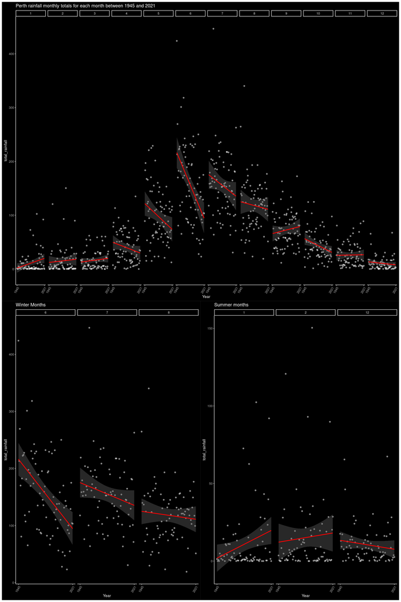

```r
min_year = rain$Year %>% min
max_year = rain$Year %>% max
rainfall_totals <- rain %>%
    group_by(Year, Month) %>%
    summarise(total_rainfall = sum(`Rainfall amount (millimetres)`))

allmonths <- rainfall_totals %>%
    filter(Year != 1944, Year != 2022) %>%
    ggplot(aes(Year, total_rainfall)) +
    facet_grid(cols=vars(Month)) +
    geom_point(alpha = 0.5) +
    geom_smooth(method="lm", colour = "red") +
    scale_x_continuous(breaks = c(min_year+1, max_year-1)) +
    ggtitle("Perth rainfall monthly totals for each month between 1945 and 2021") +
  dark_theme_classic() +
    theme(axis.text.x=element_text(angle=60,hjust=1))
winter <- rainfall_totals %>%
    filter(Year != 1944, Year != 2022, Month %in% 6:8) %>%
    ggplot(aes(Year, total_rainfall)) +
    facet_grid(cols=vars(Month)) +
    geom_point(alpha = 0.5) +
    geom_smooth(method="lm", colour = "red") +
    scale_x_continuous(breaks = c(min_year+1, max_year-1)) +
    ggtitle("Winter Months") +
  dark_theme_classic() +
    theme(axis.text.x=element_text(angle=60,hjust=1))
summer <- rainfall_totals %>%
    filter(Year != 1944, Year != 2022, Month %in% c(1:2,12)) %>%
    ggplot(aes(Year, total_rainfall)) +
    facet_grid(cols=vars(Month)) +
    geom_point(alpha = 0.5) +
    geom_smooth(method="lm", colour = "red") +
    scale_x_continuous(breaks = c(min_year+1, max_year-1)) +
    ggtitle("Summer months") +
  dark_theme_classic() +
    theme(axis.text.x=element_text(angle=60,hjust=1))
allmonths/(winter | summer)
```

```r
models.year_vs_rainfall_per_month <- rainfall_totals %>%
    mutate(Year = Year - base_year) %>%
    group_by(Month) %>%
    group_modify(~ broom::tidy(lm(total_rainfall ~ Year, data = .)))
models.year_vs_rainfall_per_month %>%
  mutate(nominal_significant = p.value < 0.05) %>%
  mutate(passes_bonferroni = p.value < 0.05/12)
```

| Month | term | estimate | std.error | statistic | p.value | nominal_significant | passes_bonferroni |
| --- | --- | --- | --- | --- | --- | --- | --- |
| 1 | (Intercept) | 2.15028305 | 4.45102830 | 0.4830980 | 6.304149e-01 | FALSE | FALSE |
| 1 | Year | 0.21550728 | 0.09789773 | 2.2013512 | 3.074623e-02 | TRUE | FALSE |
| 2 | (Intercept) | 12.53216783 | 6.05201116 | 2.0707443 | 4.177850e-02 | TRUE | FALSE |
| 2 | Year | 0.06160042 | 0.13311040 | 0.4627770 | 6.448466e-01 | FALSE | FALSE |
| 3 | (Intercept) | 13.24432234 | 3.90474500 | 3.3918533 | 1.104613e-03 | TRUE | TRUE |
| 3 | Year | 0.07576854 | 0.08588255 | 0.8822343 | 3.804320e-01 | FALSE | FALSE |
| 4 | (Intercept) | 49.03339993 | 6.69087278 | 7.3284012 | 2.101445e-10 | TRUE | TRUE |
| 4 | Year | -0.23167971 | 0.14716178 | -1.5743199 | 1.195675e-01 | FALSE | FALSE |
| 5 | (Intercept) | 121.55908228 | 11.01629901 | 11.0344756 | 1.601555e-17 | TRUE | TRUE |
| 5 | Year | -0.61754869 | 0.24384520 | -2.5325439 | 1.335840e-02 | TRUE | FALSE |

[output cut: 14 more lines]

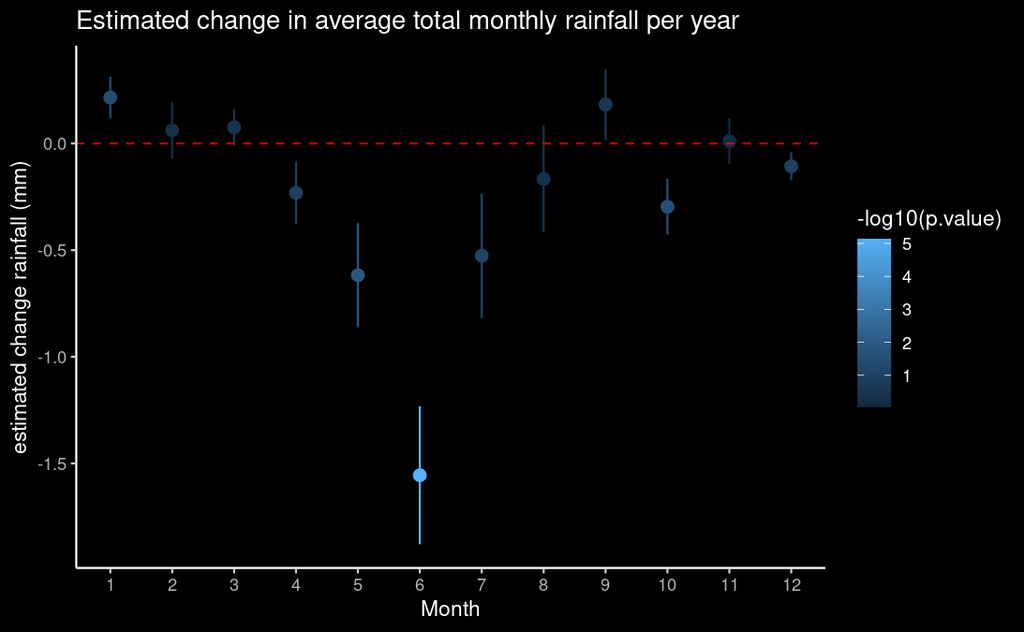

```r
models.year_vs_rainfall_per_month %>%
    filter(term == "Year") %>%
    ggplot(aes(Month, estimate, ymin=estimate-std.error, ymax=estimate+std.error, colour = -log10(p.value))) +
    dark_theme_classic() +
    geom_point() +
    geom_pointrange() +
  geom_hline(yintercept = 0, linetype = 'dashed', alpha = 0.8, colour = "red") +
    ggtitle("Estimated change in average total monthly rainfall per year") +
    ylab("estimated change rainfall (mm)") +
    scale_x_continuous(breaks = 1:12)
```

### month as an interaction term

We can also briefly pause to see how using Month as an interaction term can robustly support the hypothesis that the year-on-year change in rainfall total is influenced by the month.

In order for this to work effectively we need to modify our Month variable so that it is either a `factor` or so that the winter months are the lowest or highest valued months.

While using month as a factor avoids any assumptions about months being in a specific order, it also dilutes our test by requiring each Month to act as it’s own variable.

Instead, we can reparameterise our Month variable so that summer months have larger absolute values and winter months have smaller absolute values. We do this by subtracting the Month integer by 6 and taking the absolute value of this, leaving us with 7 unique values from 0 and 6.

```r
rainfall_totals <- rainfall_totals %>%
  mutate(Year_zeroed = Year - base_year) %>%
  mutate(Month_reparam = abs(Month-6))
year.by.month.model <- lm(total_rainfall ~ Year_zeroed*Month_reparam, data=rainfall_totals)
broom::tidy(summary(year.by.month.model))
```

| term | estimate | std.error | statistic | p.value |
| --- | --- | --- | --- | --- |
| (Intercept) | 171.7206937 | 5.95463443 | 28.838159 | 2.681424e-131 |
| Year_zeroed | -0.8493537 | 0.13233351 | -6.418281 | 2.188983e-10 |
| Month_reparam | -32.7130445 | 1.71007004 | -19.129652 | 4.364928e-69 |
| Year_zeroed:Month_reparam | 0.1937063 | 0.03805561 | 5.090086 | 4.327484e-07 |

```r
#values for text explanation
#
```

We can now run our model using rainfall totals for each month, year pair. The result shows approximately what we would expect; rainfall is estimated to be decreasing year-on-year while there is a very strong negative relationship between our reparamterised Month variable (i.e rainfall decreases with increasing values, which fits with summer (larger values) having very low rainfall). We can also see that our interaction term indicates a small, but statistically significant, interaction between Year and Month. The coefficient is positive, which supports the argument that rainfall is decreasing in winter while the relationship is weaker in the warmer months.

## is the time of peak rainfall each year changing or constant?

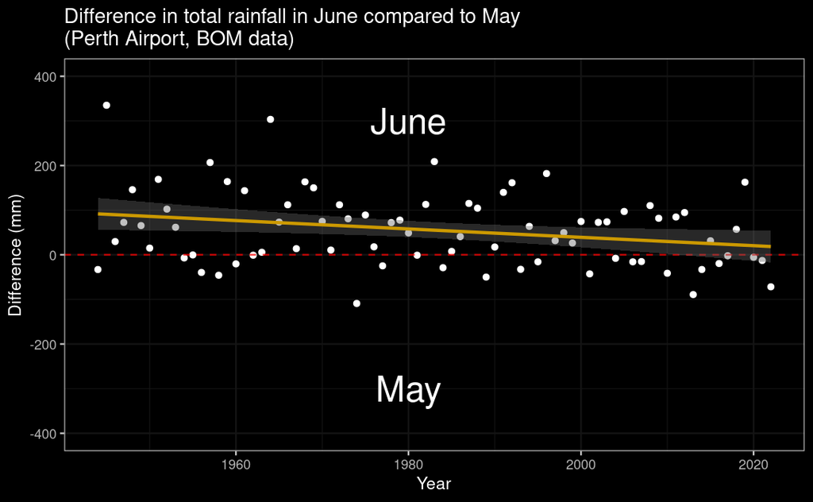

```r
rainfall_totals_may_june_higher <- rainfall_totals %>%
    filter(Month == 5 | Month == 6) %>%
    #cols become Year june july
    select(Year, Month, total_rainfall) %>%
    pivot_wider(names_from = c(Month), values_from = total_rainfall) %>%
    mutate(higher_rain = case_when(
        `5` > `6` ~ "June",
        `6` > `5` ~ "July",
    )) %>%
    mutate(higher_rain_ordinal = case_when(
        higher_rain == "May" ~ 0,
        higher_rain == "June" ~ 1
    )) %>%
    mutate(delta = `6` - `5`)
rainfall_totals_may_june_higher %>%
    ggplot(aes(Year, delta)) +
    geom_point() +
    geom_hline(yintercept = 0, linetype = 'dashed', alpha = 0.8, colour = "red") +
    geom_smooth(method="glm") +
    ggtitle("Difference in total rainfall in June compared to May\n(Perth Airport, BOM data)") +
    ylab("Difference (mm)") +
    dark_theme_bw() +
    ylim(-400,400) +
    annotate("text", label = "June", x = 1980, y = 300, size = 8) +
    annotate("text", label = "May", x = 1980, y = -300, size = 8)
```

```r
rainfall_totals_june_july_higher <- rainfall_totals %>%
    filter(Month > 5, Month < 8) %>%
    #cols become Year june july
    select(Year, Month, total_rainfall) %>%
    pivot_wider(names_from = c(Month), values_from = total_rainfall) %>%
    mutate(higher_rain = case_when(
        `6` > `7` ~ "June",
        `7` > `6` ~ "July",
    ))
rainfall_totals_june_july_higher %>%
    ggplot(aes(Year, delta)) +
    geom_point() +
    geom_hline(yintercept = 0, linetype = 'dashed', alpha = 0.8, colour = "red") +
    geom_smooth(method="glm") +
    ggtitle("Difference in total rainfall in July compared to June\n(Perth Airport, BOM data)") +
    ylab("Difference (mm)") +
    dark_theme_bw() +
    ylim(-400,400) +
    annotate("text", label = "July", x = 1980, y = 300, size = 8) +
    annotate("text", label = "June", x = 1980, y = -300, size = 8)
```

[output not shown]